# Summary of RNA-seq data cleaning

J. Shah chimeric mouse collaboration

Kim Dill-McFarland, kadm@uw.edu

version May 12, 2020

# Pipeline overview

*Command line tools*

1. Combine `.fastq.gz` files per read per sample
2. Remove sequencing adapters
3. Quality filter sequences
4. Align to reference genome
5. Quality filter alignments
6. Count reads in genes

*R*

7. Filter protein coding genes
8. Filter low coverage samples
9. Filter PCA outliers
10. Filter rare genes
11. Normalize counts

# RNA-seq data cleaning

## 1. Combine files

Samples were sequenced as 50 bp paired-end reads on a multi-lane Illumina sequencer. Therefore, there are multiple files for each sample and read. These are combined by sample and read (R1, R2) using the standard Unix function `cat`. The resulting files are in `data_raw/fastq_merge/`

For example:

```bash
cat Lu1*R1_00[0-9].fastq.gz > Lu01_R1.fastq.gz
cat Lu1*R2_00[0-9].fastq.gz > Lu01_R2.fastq.gz
```

## 2. Adapters and 3. quality filtering

### Sequence assessment 1

Sequences were assessed using [FastQC](https://www.bioinformatics.babraham.ac.uk/projects/fastqc/) to visualize sequence quality and determine if adapters exist.

Results can be found in `results/results_fastqc/fastqc_raw/`

For example:

```bash
fastqc Lu01_R1.fastq.gz \
      -o ~/results/results_fastqc/fastqc_raw/ \
      -t 15
```

Resulting in:

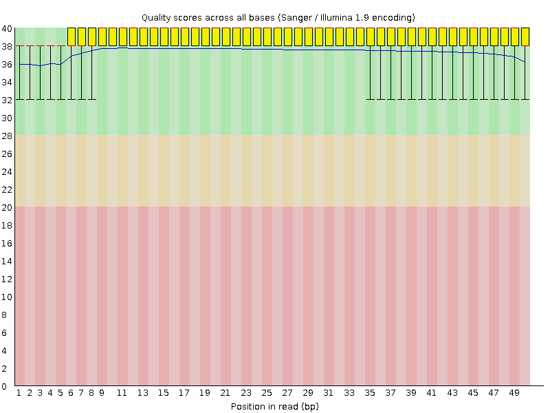

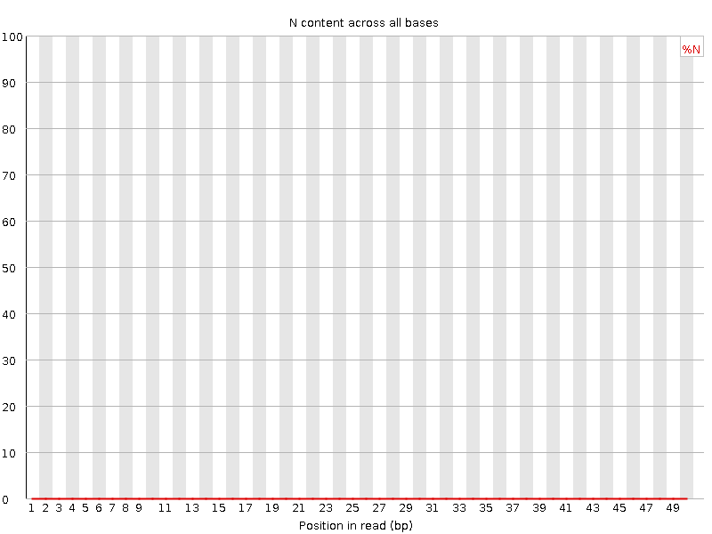

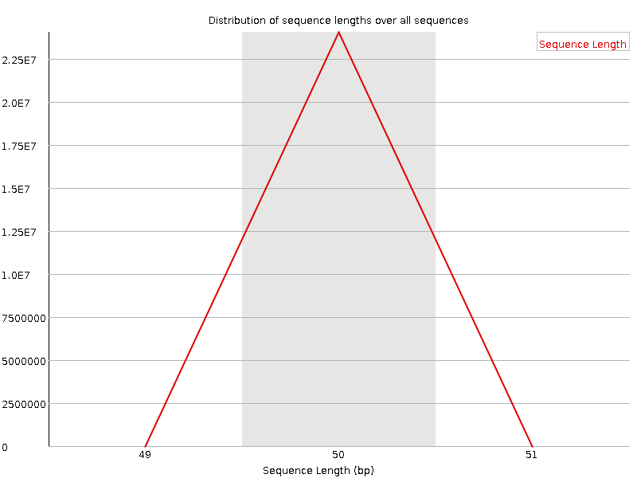

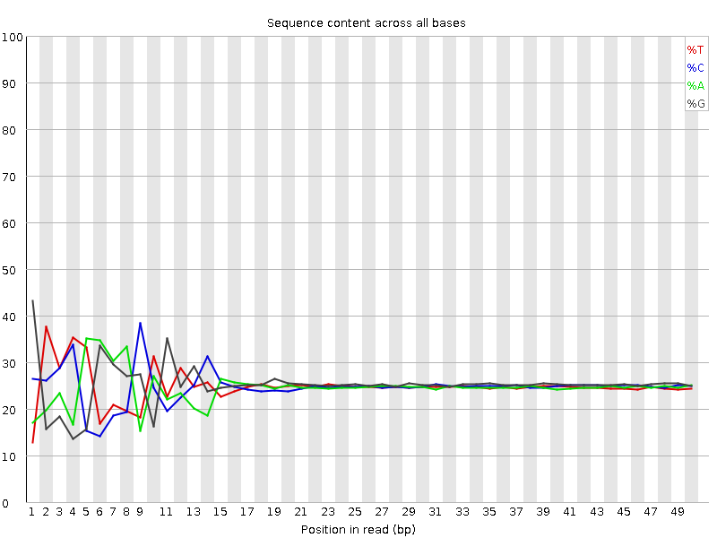

Results are similar for all samples.

Overall, read quality is high with Phred scores > 30 (upper left), minimal ambiguous bases pairs (upper right), and full length 50 bp reads (lower left).

However, there appear to be adapters present in these reads (lower right). RNA-seq randomly samples pieces of RNA expressed from the genome. Thus, if you stack all reads from a sample, each position should contain roughly 25% of each bp (ACTG). In these samples, we see that the first 15 bp are not at the expected 25%. This most commonly indicates sequencing adapters, because these sequences are the same for all reads, thus skewing the apparent bp proportions. The adapters appear in the results, because pieces of sample DNA are < 50 bp and the machine sequenced past the end of the “real data” into the adapter. The proportions along adapters are not 100%, because there is some variation in sample DNA length that causes the adapters on some sequences to be a few bp shifted relative to other sequences.

Since the adapters do not represent real biological data, they need to be removed. Also, note that these adapters are not flagged in the “Adapter Content” plot (below), because the FastQC default list does not contain all current Illumina adapter sequences.

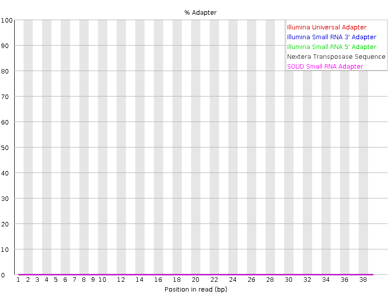

### Sequence filtering

Using [AdapterRemoval](https://github.com/MikkelSchubert/adapterremoval), sequences are filtered to

- hard cut the 5’ end of sequences by 15 bp, thus removing adapters (`trim5p`)
- remove reads with > 1 ambiguous base (`maxns`)
- trim 5’ and 3’ ends until reach base with quality of 30+ (`trimqualities minquality`)
- remove reads < 15 bp long after both end trimming steps (`minlength`)

Results can be found in `data_raw/fastq_trim/`. Note that this program changes read names from R1 > pair1 and R2 > pair2.

For example:

```bash
AdapterRemoval \
    --file1 Lu01_R1.fastq.gz \
    --file2 Lu01_R2.fastq.gz \
    --basename data_raw/fastq_trim/Lu01 --gzip \
    --trim5p 15 --maxns 1 --minlength 15 \
    --trimqualities --minquality 30 \
    --threads 15
```

### Sequence assessment 2

Using FastQC again, assess the quality of the filtered reads. Results can be found in `results/results_fastqc/fastqc_trim/`

For example:

```bash
fastqc Lu01.pair1.truncated.gz \
      -o ~/results/results_fastqc/fastqc_trim/ \
      -t 15
```

Resulting in:

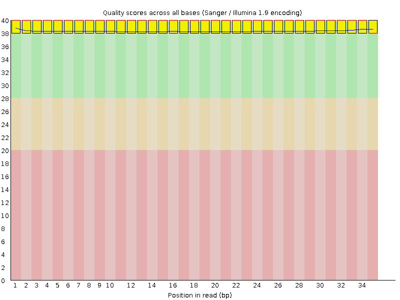

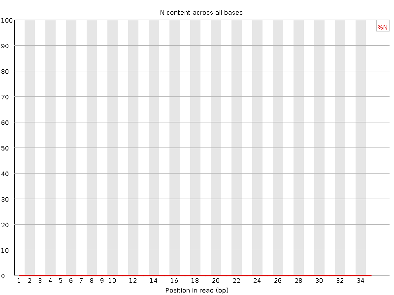

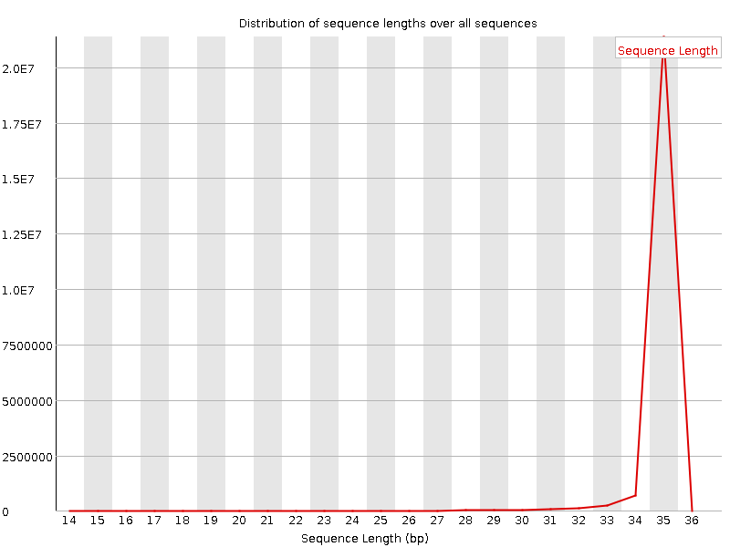

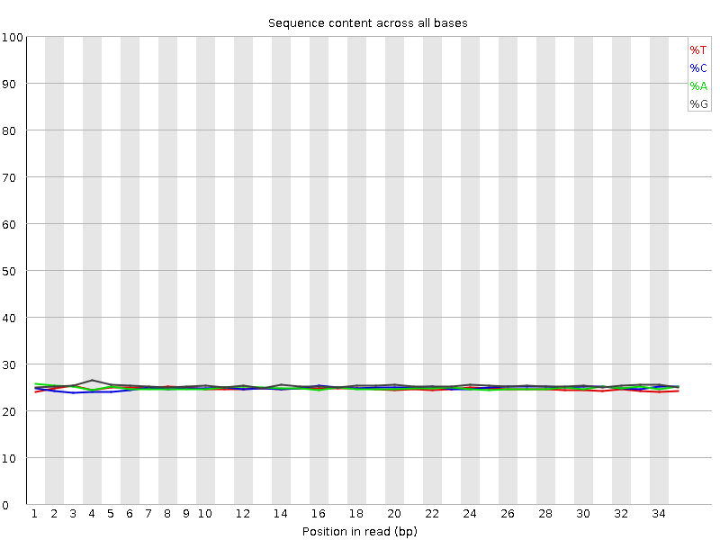

Results are similar for all samples.

Filtering achieved the desired outcomes as seen in the above plots.

## 4. Alignment

Sequences were aligned to the mouse reference genome ([GRCm38 release 99](https://uswest.ensembl.org/Mus_musculus/Info/Index) aka mm10) using STAR. This aligner is optimized for short-read data such as RNA-seq. Therefore, defaults were maintained.

Results can be found in `data_raw/bam`

For example:

```bash
#Download reference
sudo curl -O ftp://ftp.ensembl.org/pub/release-99/gtf/mus_musculus/Mus_musculus.GRCm38.99.gtf.gz
gunzip Mus_musculus.GRCm38.99.gtf.gz

sudo curl -O ftp://ftp.ensembl.org/pub/release-99/fasta/mus_musculus/dna/Mus_musculus.GRCm38.dna.primary_assembly.fa.gz
gunzip Mus_musculus.GRCm38.dna.primary_assembly.fa.gz

#Index reference
STAR --runMode genomeGenerate \
     --genomeDir STARindex.mouse \
     --genomeFastaFiles Mus_musculus.GRCm38.dna.primary_assembly.fa \
     --sjdbGTFfile Mus_musculus.GRCm38.99.gtf \
     --sjdbOverhang 99 \
     --runThreadN 15

#Align
STAR --genomeDir STARindex.mouse \
     --readFilesIn Lu01.pair1.truncated.gz Lu01.pair2.truncated.gz \
     --readFilesCommand zcat \
     --outFileNamePrefix Lu01 \
     --outSAMtype BAM SortedByCoordinate \
     --runThreadN 15 \
     --runRNGseed 8756
```

## 5. Alignment filtering

### Alignment assessment

Alignment quality was assessed with [Picard](https://broadinstitute.github.io/picard/) and [samtools flagstat](http://www.htslib.org/doc/samtools-flagstat.html).

Picard results can be found in `results/results_cleaning/bam.metrics.tsv` and flagstat in `results/results_cleaning/summary.alignment.tsv`.

For example:

```bash
#Download Picard reference
sudo curl -O http://hgdownload.cse.ucsc.edu/goldenpath/mm10/database/refFlat.txt.gz
gunzip -c refFlat.txt.gz > refFlat.mouse.txt
## Remove chr in chromosome name to match ensembl alignment
sed 's/chr//' refFlat.mouse.txt > refFlat.mouse.ensembl.txt

#Assess alignment with Picard
java -XX:ParallelGCThreads=15 \
    -jar picard-2.22.1-0/picard.jar \
    CollectRnaSeqMetrics \
    REF_FLAT=refFlat.mouse.ensembl.txt \
    INPUT=Lu01_Aligned.sortedByCoord.out.bam \
    OUTPUT=results/results_cleaning/bam.metrics.tsv \
    ASSUME_SORTED=true \
    STRAND_SPECIFICITY=NONE \
    MINIMUM_LENGTH=500

#Assess alignment with samtools
samtools flagstat -@ 15 Lu01_Aligned.sortedByCoord.out.bam \
    >> results/results_cleaning/summary.alignment.tsv
```

### Alignment filtering

Alignments were quality filtered using [samtools view](http://www.htslib.org/doc/samtools-view.html) to:

- keep the file header (`h`)
- keep paired reads where both reads mapped to the genome (`-f 3`)
- remove unmapped reads, non-primary alignments, and PCR duplicates (`-F 1284`)
- remove reads with a mapping quality (MAPQ) < 30 (`-q 30`)

See this [explanation of flags](http://broadinstitute.github.io/picard/explain-flags.html) for more details on the numbers used here.

Results can be found in `data_raw/bam_filter_paired`

For example:

```bash
samtools view Lu01_Aligned.sortedByCoord.out.bam \
    -h -f 3 -F 1284 -q 30 \
    -@ 15 \
    > Lu01_filter_paired.bam
```

### Alignment assessment 2

Filtering alignments were then re-assessed with samtools flagstat.

Results can be found in `results/results_cleaning/summary.align.filter.paired.tsv`

For example:

```bash
samtools flagstat -@ 15 Lu01_filter_paired.bam \
    >> results/results_cleaning/summary.align.filter.paired.tsv
```

## 6. Count reads in genes

Total reads in genes were quantified using [SUBREAD featureCounts](http://subread.sourceforge.net/). Only reads in exons of known genes were counted.

Results can be found in `data_raw/counts`

For example:

```bash
featureCounts -T 14 -g gene_id -t exon -p \
  -a Mus_musculus.GRCm38.99.gtf \
  -o Shah.featurecounts.paired.tsv \
  bam_filter_paired/*filter_paired.bam
```

Counts were further formatted using `scripts/RNAseq_counts_formatting.R` to results in `data_clean/Shah.counts.clean.csv`

```
## # A tibble: 55,471 x 17
##    geneName  Lu01  Lu02  Lu03  Lu04  Lu05  Lu06  Lu07  Lu08  Lu09  Lu10  Lu11
##    <chr>    <dbl> <dbl> <dbl> <dbl> <dbl> <dbl> <dbl> <dbl> <dbl> <dbl> <dbl>
##  1 ENSMUSG…     0     0     0     0     0     0     0     0     0     0     0
##  2 ENSMUSG…     0     0     0     0     0     0     0     0     0     0     0
##  3 ENSMUSG…     0     0     0     0     0     0     0     0     0     0     0
##  4 ENSMUSG…     0     0     0     0     0     0     0     0     0     0     0
##  5 ENSMUSG…     0     0     0     0     0     0     0     0     0     0     0
##  6 ENSMUSG…     1     0     0     0     0     0     0     0     0     0     0
##  7 ENSMUSG…     0     0     0     0     0     0     0     0     0     0     0
##  8 ENSMUSG…     0     0     0     0     0     0     0     0     0     0     0
##  9 ENSMUSG…     0     0     0     0     0     0     0     0     0     0     0
## 10 ENSMUSG…     1     0     1     1     1     0     0     0     0     0     0
## # … with 55,461 more rows, and 5 more variables: Lu12 <dbl>, Lu13 <dbl>,
## #   Lu14 <dbl>, Lu15 <dbl>, Lu16 <dbl>
```

## Summary 1

See `scripts/RNAseq_summary_formatting.R` for details on plot creation.

**Total sequences retained during cleaning**

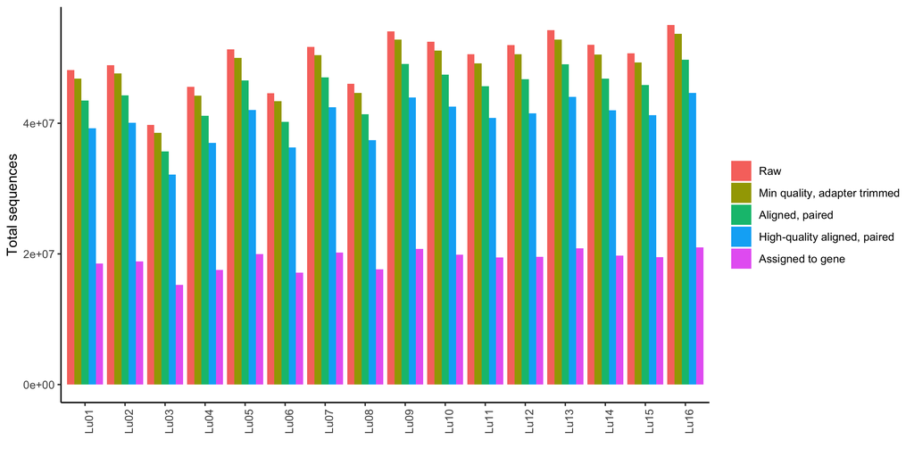

**Percent of raw sequences retained during cleaning**

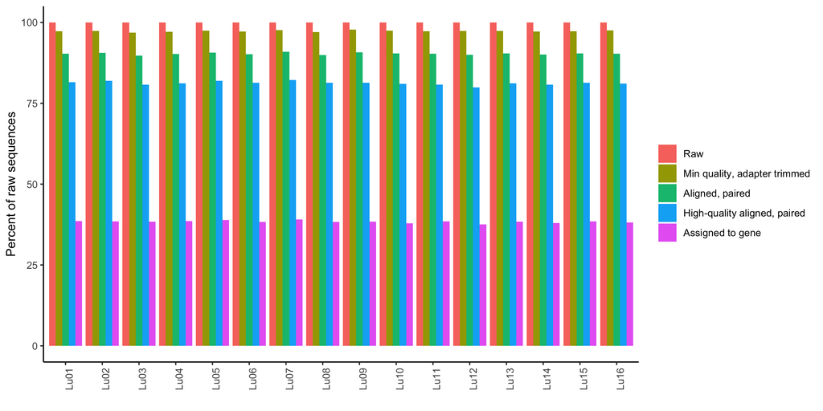

**Final quality**

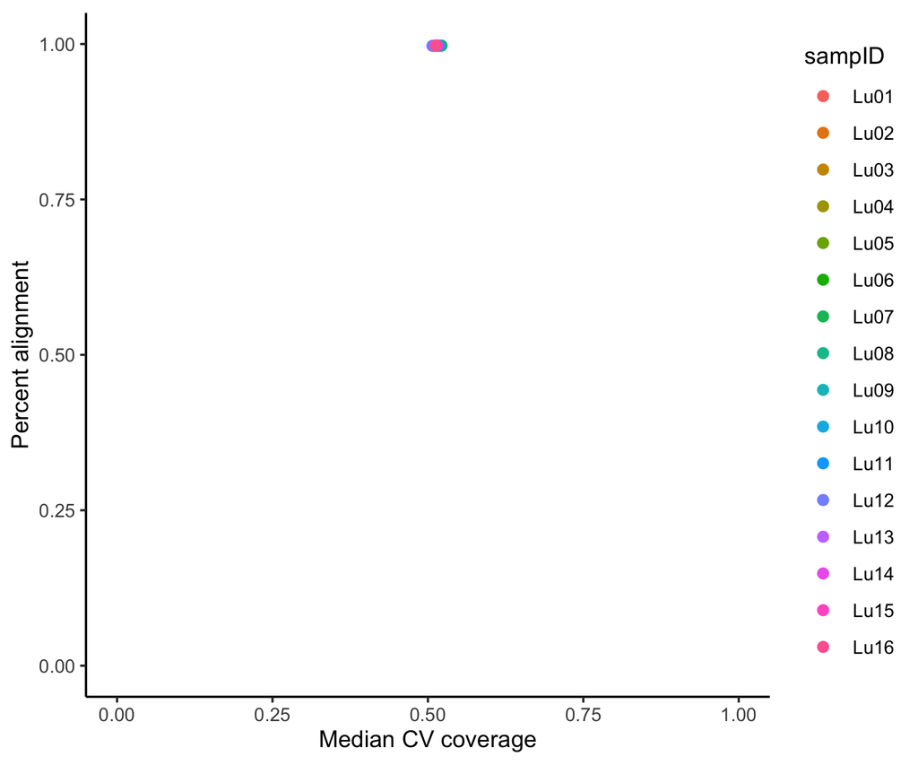

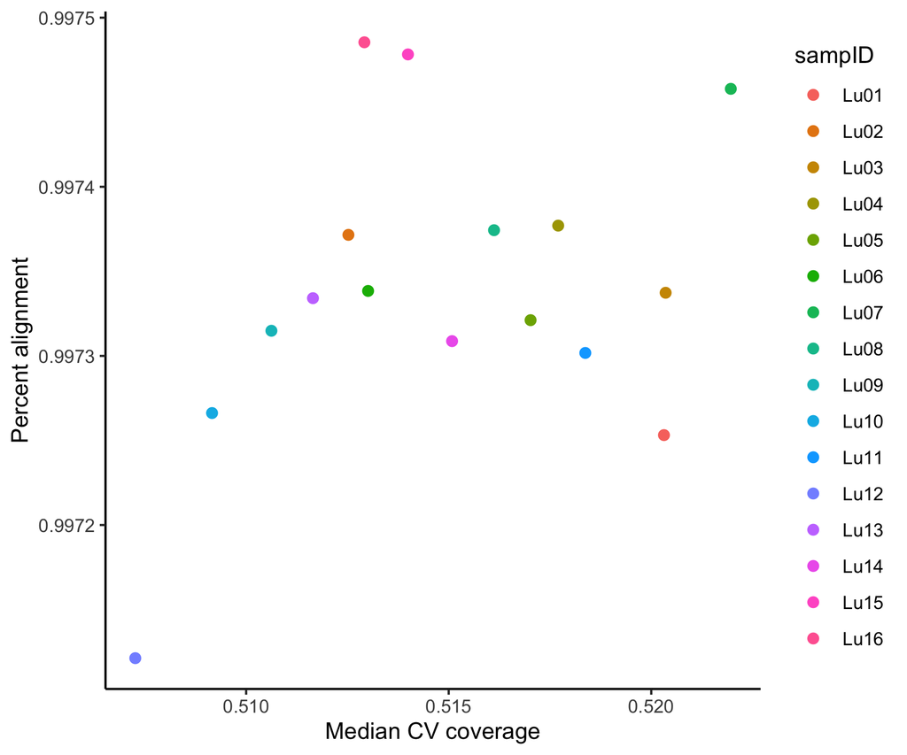

Overall, these samples are very high-quality with > 32 million clean, aligned sequences per sample and low variability in gene coverage (*e.g.* median CV coverage). As expected, ~20% of raw sequences were removed for sequence or alignment quality.

A minimum of 15 million sequences were assigned to genes in each sample. This is more than sufficient for desired analyses.